# Module11_Homework

Nick Wlodychak

2023-12-10

# Introduction

Cancer genomics is a rapidly growing and expanding field of bioinformatics investigating genetic abnormalities in cancer cells. Data architecture and formatting is critical in a disease with so many intricacies and interactions. The Mutation Annotation Format (MAF) is a commonly used format that stores aggregated mutation information from Variant Call Format (VCF) files.

In this tutorial we use `maftools`, a powerful R library utilized for the summation of MAF files, visualization of somatic mutations through oncoplots (waterfall plots), and analysis of oncogenomic data-sets. `maftools` possesses categorical visualization and analysis modules.

# **Reading and summarizing `maf` files**

The first step in our tutorial is to read our `maf` file with the function **`read.maf`**. This function summarizes `maf` in various ways, and stores the summarized data as an MAF object. Additionally the function can integrate copy number data from GISTIC or a custom table containing gene name, sample name, and copy number status.

Following incorporation of our `maf` file as a variable, we can summarize and view the data set with functions such as `getSampleSummary` and `getFields`. These functions can help with downstream variable assignment and data integrity.

```r
library(maftools)
#path to TCGA LAML MAF file
laml.maf = system.file('extdata', 'tcga_laml.maf.gz', package = 'maftools')
#clinical information containing survival information and histology. This is optional
laml.clin = system.file('extdata', 'tcga_laml_annot.tsv', package = 'maftools')
laml = read.maf(maf = laml.maf, clinicalData = laml.clin)
```

```
## -Reading
## -Validating
## -Silent variants: 475
## -Summarizing
## -Processing clinical data
## -Finished in 0.364s elapsed (0.353s cpu)
```

```r
#Typing laml shows basic summary of MAF file.
```

```r
laml
```

```
## An object of class  MAF
##                    ID          summary  Mean Median
##  1:        NCBI_Build               37    NA     NA
##  2:            Center genome.wustl.edu    NA     NA
##  3:           Samples              193    NA     NA
##  4:            nGenes             1241    NA     NA
##  5:   Frame_Shift_Del               52 0.271      0
##  6:   Frame_Shift_Ins               91 0.474      0
##  7:      In_Frame_Del               10 0.052      0
##  8:      In_Frame_Ins               42 0.219      0
##  9: Missense_Mutation             1342 6.990      7
## 10: Nonsense_Mutation              103 0.536      0
## 11:       Splice_Site               92 0.479      0
## 12:             total             1732 9.021      9
```

```r
#Shows sample summry.
getSampleSummary(laml)
```

```
##      Tumor_Sample_Barcode Frame_Shift_Del Frame_Shift_Ins In_Frame_Del
##   1:         TCGA-AB-3009               0               5            0
##   2:         TCGA-AB-2807               1               0            1
##   3:         TCGA-AB-2959               0               0            0
##   4:         TCGA-AB-3002               0               0            0
##   5:         TCGA-AB-2849               0               1            0
##  ---
## 188:         TCGA-AB-2933               0               0            0
## 189:         TCGA-AB-2942               0               0            0
## 190:         TCGA-AB-2946               0               0            0
## 191:         TCGA-AB-2954               0               0            0
## 192:         TCGA-AB-2982               0               0            0
##      In_Frame_Ins Missense_Mutation Nonsense_Mutation Splice_Site total
##   1:            1                25                 2           1    34
##   2:            0                16                 3           4    25
##   3:            0                22                 0           1    23
##   4:            0                15                 1           5    21
##   5:            0                16                 1           2    20
##  ---
## 188:            0                 1                 0           0     1
## 189:            1                 0                 0           0     1
## 190:            0                 1                 0           0     1
## 191:            0                 1                 0           0     1
## 192:            0                 1                 0           0     1
```

```r
#Shows gene summary.
getGeneSummary(laml)
```

```
##       Hugo_Symbol Frame_Shift_Del Frame_Shift_Ins In_Frame_Del In_Frame_Ins
##    1:        FLT3               0               0            1           33
##    2:      DNMT3A               4               0            0            0
##    3:        NPM1               0              33            0            0
##    4:        IDH2               0               0            0            0
##    5:        IDH1               0               0            0            0
##   ---
## 1237:      ZNF689               0               0            0            0
## 1238:      ZNF75D               0               0            0            0
## 1239:      ZNF827               1               0            0            0
## 1240:       ZNF99               0               0            0            0
## 1241:        ZPBP               0               0            0            0
##       Missense_Mutation Nonsense_Mutation Splice_Site total MutatedSamples
##    1:                15                 0           3    52             52
##    2:                39                 5           6    54             48
```

[output cut: 21 more lines]

```r
#shows clinical data associated with samples
getClinicalData(laml)
```

```
##      Tumor_Sample_Barcode FAB_classification days_to_last_followup
##   1:         TCGA-AB-2802                 M4                   365
##   2:         TCGA-AB-2803                 M3                   792
##   3:         TCGA-AB-2804                 M3                  2557
##   4:         TCGA-AB-2805                 M0                   577
##   5:         TCGA-AB-2806                 M1                   945
##  ---
## 189:         TCGA-AB-3007                 M3                  1581
## 190:         TCGA-AB-3008                 M1                   822
## 191:         TCGA-AB-3009                 M4                   577
## 192:         TCGA-AB-3011                 M1                  1885
## 193:         TCGA-AB-3012                 M3                  1887
##      Overall_Survival_Status
##   1:                       1
##   2:                       1
##   3:                       0
##   4:                       1
##   5:                       1
##  ---
## 189:                       0
## 190:                       1
## 191:                       1
## 192:                       0
## 193:                       0
```

```r
#Shows all fields in MAF
getFields(laml)
```

```
##  [1] "Hugo_Symbol"            "Entrez_Gene_Id"         "Center"
##  [4] "NCBI_Build"             "Chromosome"             "Start_Position"
##  [7] "End_Position"           "Strand"                 "Variant_Classification"
## [10] "Variant_Type"           "Reference_Allele"       "Tumor_Seq_Allele1"
## [13] "Tumor_Seq_Allele2"      "Tumor_Sample_Barcode"   "Protein_Change"
## [16] "i_TumorVAF_WU"          "i_transcript_name"
```

```r
#Writes maf summary to an output file with basename laml.
write.mafSummary(maf = laml, basename = 'laml')
```

# **Visualization modules**

Good data visualization is critical to the success of any bioinformatician. Conveying significance and values of observations assits in general understanding of a dataset. the maftools package posesses a robust suite of visualization tools that plot a variety of variables including `VAF` and mutational loads

Below we show a group of plots generated via `plotmafSummary`. Each plot is a different method of representing the data to give a comprehensive view of the mutation landscape within the studied samples. This is useful understanding patterns and frequencies of various types of genomic alterations in cancer. Higlights include:

- **Variant Classification** for determination of mutation type.
- **SNV Class** plotting of single nucleotide variants (SNVs) showing the different base changes
- **Top 10 Mutated Genes** lists the top 10 genes with mutations.

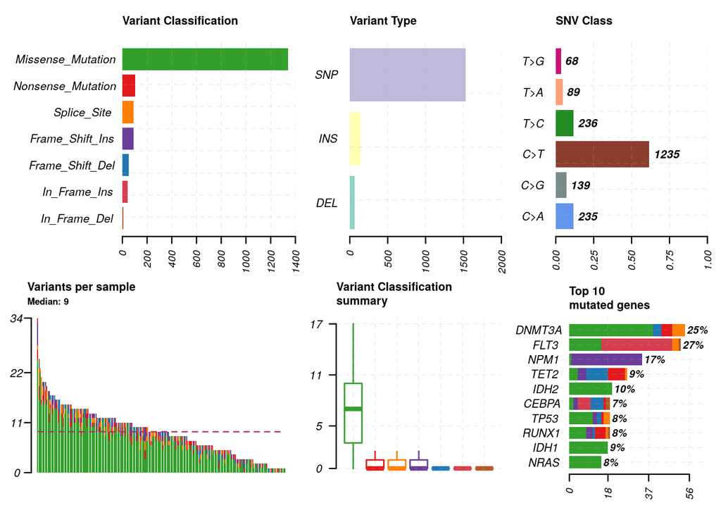

```r
plotmafSummary(maf = laml, rmOutlier = TRUE, addStat = 'median', dashboard = TRUE, titvRaw = FALSE)
```

### Oncoplots

Below we show an oncoplot which is similar to a histogram for 193 samples in the data-set. Mutations are altered in 141 out of 193 samples, accounting for 73.06% of the cohort. Different mutations are represented in the color key which the top histogram shows the Tumor mutation burden (TMB) across the samples. Genes are stacked as the top mutated genes found in these samples.

This type of plot is useful for observing mutational load within a population and also analyzing the frequency of gene specific mutations and their genomic loci.

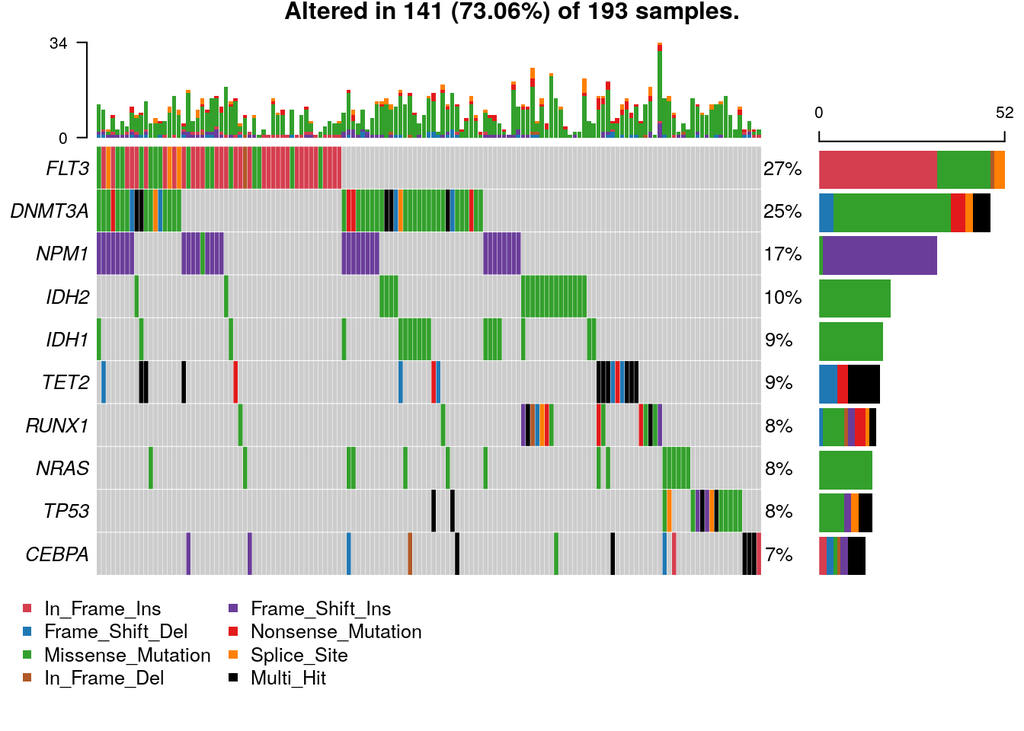

```r
#oncoplot for top ten mutated genes.
oncoplot(maf = laml, top = 10)
```

### Transition and Transversions

This boxplots for displays the common nucleotide changes (C>T, C>A, T>A) and the transition/transversion (Ti/Tv) ratio in mutations. In our plot, a high number of C>T transitions suggest a possible signature of UV-light induced damage or spontaneous deamination of 5-methylcytosine.

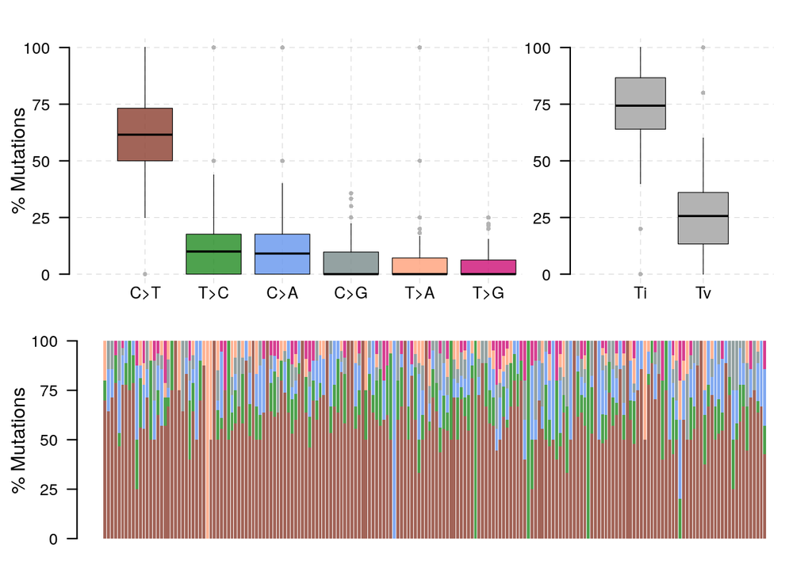

```r
laml.titv = titv(maf = laml, plot = FALSE, useSyn = TRUE)
#plot titv summary
plotTiTv(res = laml.titv)
```

### Rainfall plots

This graph illustrates the distribution of mutations across all chromosomes in a single sample. Each dot in a rainfall plot represents a mutation, with its color indicating the type of nucleotide change. The y-axis shows the log10 of the inter-event distance — tight clusters may suggest kataegis or localized hypermutation.

```
## Processing TCGA-A8-A08B..
```

```
## Kataegis detected at:
```

```
##    Chromosome Start_Position End_Position nMuts Avg_intermutation_dist Size
## 1:          8       98129391     98133560     6               833.8000 4169
## 2:          8       98398603     98403536     8               704.7143 4933
## 3:          8       98453111     98456466     8               479.2857 3355
## 4:          8      124090506    124096810    21               315.2000 6304
## 5:         12       97437934     97439705     6               354.2000 1771
## 6:         17       29332130     29336153     7               670.5000 4023
##    Tumor_Sample_Barcode C>G C>T
## 1:         TCGA-A8-A08B   4   2
## 2:         TCGA-A8-A08B   1   7
## 3:         TCGA-A8-A08B  NA   8
## 4:         TCGA-A8-A08B   1  20
## 5:         TCGA-A8-A08B   3   3
## 6:         TCGA-A8-A08B   4   3
```

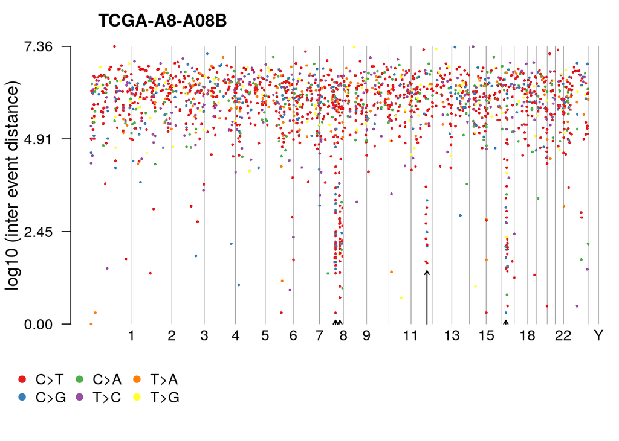

```r
brca <- system.file("extdata", "brca.maf.gz", package = "maftools")
brca = read.maf(maf = brca, verbose = FALSE)
rainfallPlot(maf = brca, detectChangePoints = TRUE, pointSize = 0.4)
```

### Mutation load

This plot displays the tumor mutation burden (TMB) across various cancer types, with each dot representing a sample. The y-axis is on a logarithmic scale, indicating the number of mutations per megabase (MB) of tumor DNA. The red line indicates the median TMB for each cancer type, displaying the variability in mutation load across different cancers subsets.

```r
laml.mutload = tcgaCompare(maf = laml, cohortName = 'Example-LAML', logscale = TRUE, capture_size = 50)
```

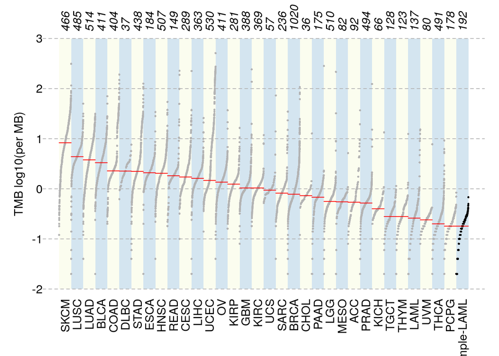

### Plotting VAF

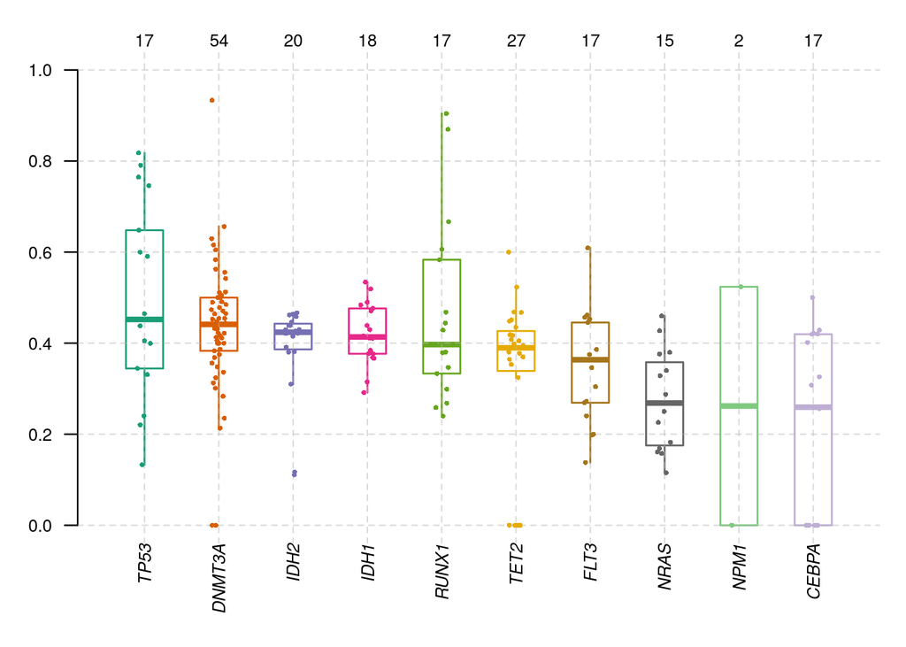

```r
plotVaf(maf = laml, vafCol = 'i_TumorVAF_WU')
```

# Analysis Modules

### Somatic Interactions

The plot below plot displays the statistical relationship between mutations in different genes. The shading of each cell indicates the significance value with the strength of evidence for co-occurrence or mutual exclusivity of mutations.

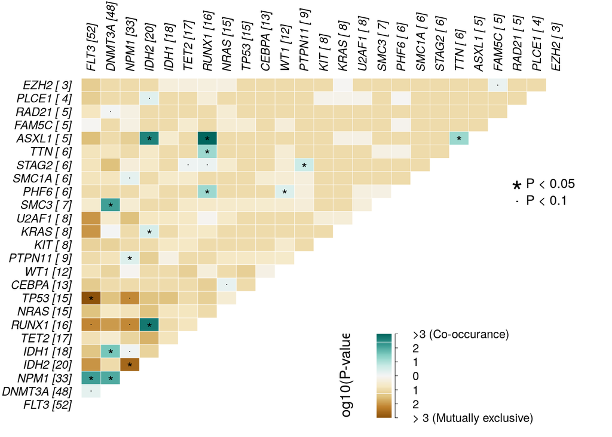

```
##      gene1  gene2       pValue oddsRatio  00 11 01 10              Event
##   1: ASXL1  RUNX1 0.0001541586 55.215541 176  4 12  1       Co_Occurence
##   2:  IDH2  RUNX1 0.0002809928  9.590877 164  7  9 13       Co_Occurence
##   3:  IDH2  ASXL1 0.0004030636 41.077327 172  4  1 16       Co_Occurence
##   4:  FLT3   NPM1 0.0009929836  3.763161 125 17 16 35       Co_Occurence
##   5:  SMC3 DNMT3A 0.0010451985 20.177713 144  6 42  1       Co_Occurence
##  ---
## 296: PLCE1  ASXL1 1.0000000000  0.000000 184  0  5  4 Mutually_Exclusive
## 297: RAD21  FAM5C 1.0000000000  0.000000 183  0  5  5 Mutually_Exclusive
## 298: PLCE1  FAM5C 1.0000000000  0.000000 184  0  5  4 Mutually_Exclusive
## 299: PLCE1  RAD21 1.0000000000  0.000000 184  0  5  4 Mutually_Exclusive
## 300:  EZH2  PLCE1 1.0000000000  0.000000 186  0  4  3 Mutually_Exclusive
##              pair event_ratio
##   1: ASXL1, RUNX1        4/13
##   2:  IDH2, RUNX1        7/22
##   3:  ASXL1, IDH2        4/17
##   4:   FLT3, NPM1       17/51
##   5: DNMT3A, SMC3        6/43
##  ---
## 296: ASXL1, PLCE1         0/9
## 297: FAM5C, RAD21        0/10
## 298: FAM5C, PLCE1         0/9
## 299: PLCE1, RAD21         0/9
## 300:  EZH2, PLCE1         0/7
```

```r
somaticInteractions(maf = laml, top = 25, pvalue = c(0.05, 0.1))
```

### Oncodrive

The function `oncodrive` identifies cancer genes (driver) from a given MAF. This function is based on cancer causing variants being enriched at some specific loci. By analyzing such positions we can identify cancer causing genes.

This plotting then plots the results as scatter plot size being indicative of the number of hot-spots in the gene clusters.

```r
laml.sig = oncodrive(maf = laml, AACol = 'Protein_Change', minMut = 5, pvalMethod = 'zscore')
```

```
## Estimating background scores from synonymous variants..
```

```
## Not enough genes to build background. Using predefined values. (Mean = 0.279; SD = 0.13)
```

```
## Estimating cluster scores from non-syn variants..
```

```
## Comapring with background model and estimating p-values..
```

```
## Done !
```

```r
head(laml.sig)
```

```
##    Hugo_Symbol Frame_Shift_Del Frame_Shift_Ins In_Frame_Del In_Frame_Ins
## 1:        IDH1               0               0            0            0
## 2:        IDH2               0               0            0            0
## 3:        NPM1               0              33            0            0
## 4:        NRAS               0               0            0            0
## 5:       U2AF1               0               0            0            0
## 6:         KIT               1               1            0            1
##    Missense_Mutation Nonsense_Mutation Splice_Site total MutatedSamples
## 1:                18                 0           0    18             18
## 2:                20                 0           0    20             20
## 3:                 1                 0           0    34             33
## 4:                15                 0           0    15             15
## 5:                 8                 0           0     8              8
## 6:                 7                 0           0    10              8
##    AlteredSamples clusters muts_in_clusters clusterScores protLen   zscore
## 1:             18        1               18     1.0000000     414 5.546154
## 2:             20        2               20     1.0000000     452 5.546154
## 3:             33        2               32     0.9411765     294 5.093665
## 4:             15        2               15     0.9218951     189 4.945347
## 5:              8        1                7     0.8750000     240 4.584615
## 6:              8        2                9     0.8500000     976 4.392308
##            pval          fdr fract_muts_in_clusters
## 1: 1.460110e-08 1.022077e-07              1.0000000
## 2: 1.460110e-08 1.022077e-07              1.0000000
## 3: 1.756034e-07 8.194826e-07              0.9411765
## 4: 3.800413e-07 1.330144e-06              1.0000000
## 5: 2.274114e-06 6.367520e-06              0.8750000
## 6: 5.607691e-06 1.308461e-05              0.9000000
```

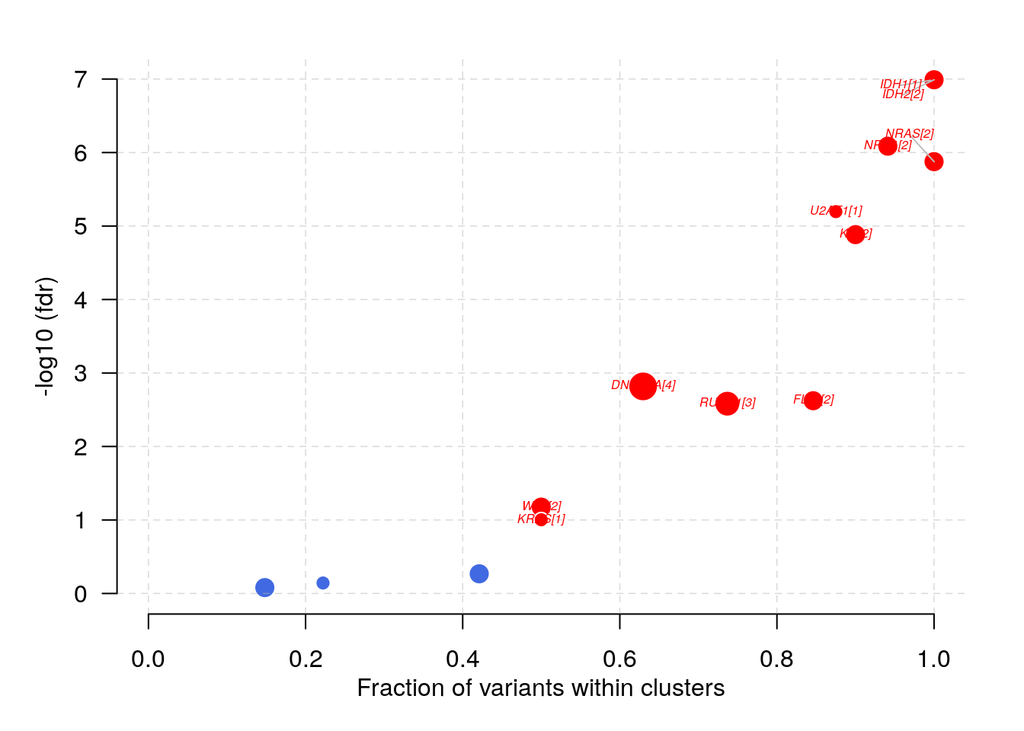

```r
plotOncodrive(res = laml.sig, fdrCutOff = 0.1, useFraction = TRUE, labelSize = 0.5)
```

### **Adding and summarizing pfam domains**

The `pfamDomain` function identifies amino acid changes according to the domains that are affected. From these mutations we can identify which protein domain is most affected within a cancer cohort.

```r
laml.pfam = pfamDomains(maf = laml, AACol = 'Protein_Change', top = 10)
```

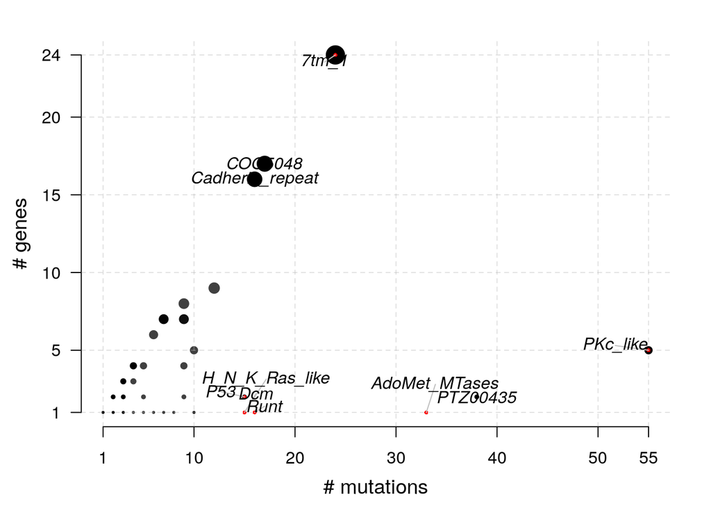

```r
laml.pfam$proteinSummary[,1:7, with = FALSE]
```

```
##         HGNC AAPos Variant_Classification  N total  fraction   DomainLabel
##    1: DNMT3A   882      Missense_Mutation 27    54 0.5000000 AdoMet_MTases
##    2:   IDH1   132      Missense_Mutation 18    18 1.0000000      PTZ00435
##    3:   IDH2   140      Missense_Mutation 17    20 0.8500000      PTZ00435
##    4:   FLT3   835      Missense_Mutation 14    52 0.2692308      PKc_like
##    5:   FLT3   599           In_Frame_Ins 10    52 0.1923077      PKc_like
##   ---
## 1512: ZNF646   875      Missense_Mutation  1     1 1.0000000          <NA>
## 1513: ZNF687   554      Missense_Mutation  1     2 0.5000000          <NA>
## 1514: ZNF687   363      Missense_Mutation  1     2 0.5000000          <NA>
## 1515: ZNF75D     5      Missense_Mutation  1     1 1.0000000          <NA>
## 1516: ZNF827   427        Frame_Shift_Del  1     1 1.0000000          <NA>
```

```r
laml.pfam$domainSummary[,1:3, with = FALSE]
```

```
##        DomainLabel nMuts nGenes
##   1:      PKc_like    55      5
##   2:      PTZ00435    38      2
##   3: AdoMet_MTases    33      1
##   4:         7tm_1    24     24
##   5:       COG5048    17     17
##  ---
## 499:    ribokinase     1      1
## 500:   rim_protein     1      1
## 501: sigpep_I_bact     1      1
## 502:           trp     1      1
## 503:        zf-BED     1      1
```

### Survival Analysis

The survival curve compares the survival probability over time between two groups with DMT3A (a methyltransferase) - mutant genes (Mutant) and wild-type (WT) genes. The significantly different survival curves, along with the P-value (7e-04) and hazard ratio (HR: 1.98), indicate that having the mutant gene is associated with a worse survival outcome compared to the wild-type, suggesting the mutation’s potential role as a prognostic indicator.

```r
mafSurvival(maf = laml, genes = 'DNMT3A', time = 'days_to_last_followup', Status = 'Overall_Survival_Status', isTCGA = TRUE)
```

```
## Looking for clinical data in annoatation slot of MAF..
```

```
## Number of mutated samples for given genes:
```

```
## DNMT3A
##     48
```

```
## Removed 11 samples with NA's
```

```
## Median survival..
```

```
##     Group medianTime   N
## 1: Mutant        245  45
## 2:     WT        396 137
```

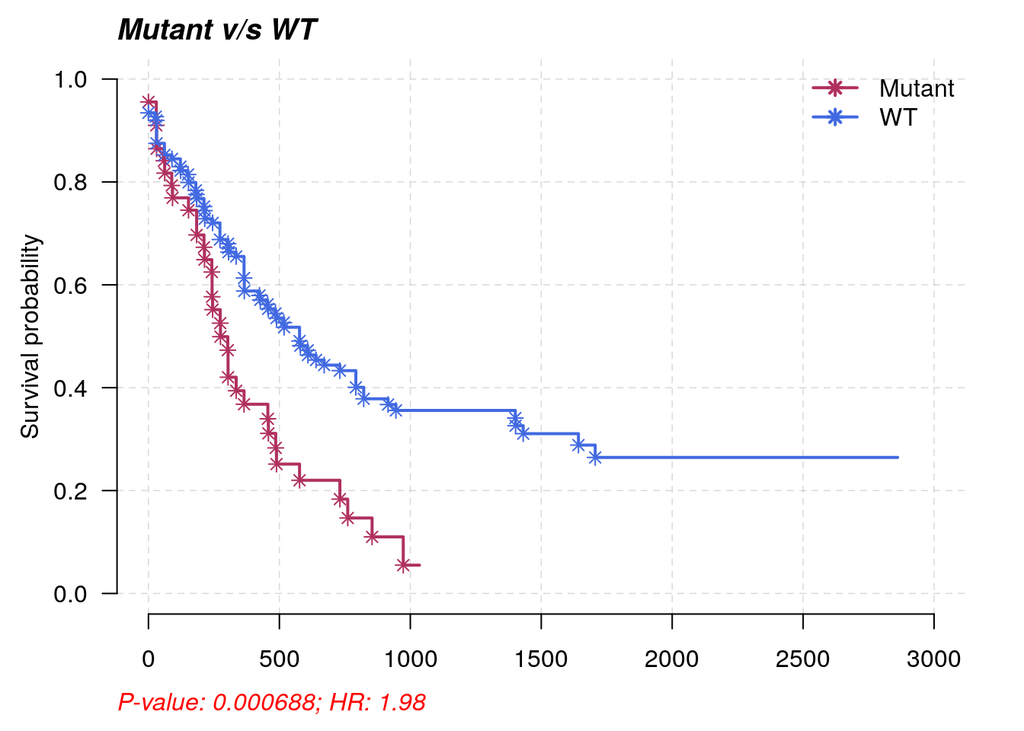

```r
prog_geneset = survGroup(maf = laml, top = 20, geneSetSize = 2, time = "days_to_last_followup", Status = "Overall_Survival_Status", verbose = FALSE)
```

```
## Removed 11 samples with NA's
```

```r
print(prog_geneset)
```

```
##     Gene_combination P_value    hr  WT Mutant
##  1:      FLT3_DNMT3A 0.00104 2.510 164     18
##  2:      DNMT3A_SMC3 0.04880 2.220 176      6
##  3:      DNMT3A_NPM1 0.07190 1.720 166     16
##  4:      DNMT3A_TET2 0.19600 1.780 176      6
##  5:        FLT3_TET2 0.20700 1.860 177      5
##  6:        NPM1_IDH1 0.21900 0.495 176      6
##  7:      DNMT3A_IDH1 0.29300 1.500 173      9
##  8:       IDH2_RUNX1 0.31800 1.580 176      6
##  9:        FLT3_NPM1 0.53600 1.210 165     17
## 10:      DNMT3A_IDH2 0.68000 0.747 178      4
## 11:      DNMT3A_NRAS 0.99200 0.986 178      4
```

```r
mafSurvGroup(maf = laml, geneSet = c("DNMT3A", "FLT3"), time = "days_to_last_followup", Status = "Overall_Survival_Status")
```

```
## Looking for clinical data in annoatation slot of MAF..
```

```
## Removed 11 samples with NA's
```

```
## Median survival..
```

```
##     Group medianTime   N
## 1: Mutant      242.5  18
## 2:     WT      379.5 164
```

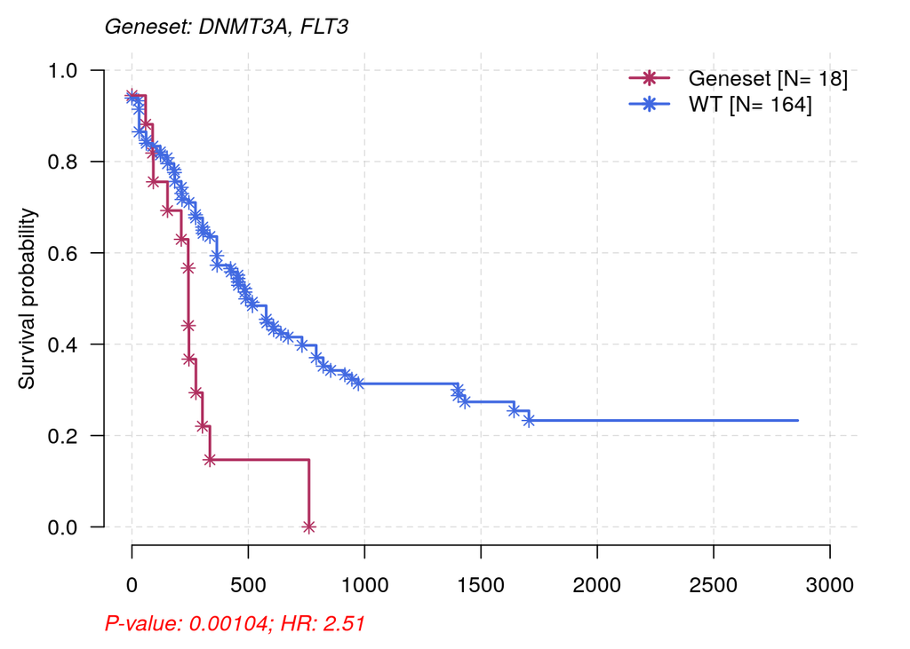

### Relapse versus Primary Comparison Plots

This plot compares the frequency of certain gene mutations in relapsed versus primary cancer cases, represented by the odds ratio (OR). Genes like *PML*, *RARA*, and *RUNX1* show a higher mutation frequency in relapse (indicated by OR less than 1), suggesting these mutations could be associated with relapse. *FLT3* shows an OR greater than 1, indicating more frequent mutations in primary cases.

```r
#Primary APL MAF
primary.apl = system.file("extdata", "APL_primary.maf.gz", package = "maftools")
primary.apl = read.maf(maf = primary.apl)
```

```
## -Reading
## -Validating
## --Non MAF specific values in Variant_Classification column:
##   ITD
## -Silent variants: 45
## -Summarizing
## -Processing clinical data
## --Missing clinical data
## -Finished in 0.128s elapsed (0.152s cpu)
```

```r
#Relapse APL MAF
relapse.apl = system.file("extdata", "APL_relapse.maf.gz", package = "maftools")
relapse.apl = read.maf(maf = relapse.apl)
```

```
## -Reading
## -Validating
## --Non MAF specific values in Variant_Classification column:
##   ITD
## -Silent variants: 19
## -Summarizing
## -Processing clinical data
## --Missing clinical data
## -Finished in 0.125s elapsed (0.156s cpu)
```

```r
#Considering only genes which are mutated in at-least in 5 samples in one of the cohort to avoid bias due to genes mutated in single sample.
pt.vs.rt <- mafCompare(m1 = primary.apl, m2 = relapse.apl, m1Name = 'Primary', m2Name = 'Relapse', minMut = 5)
print(pt.vs.rt)
```

```
## $results
##    Hugo_Symbol Primary Relapse         pval         or       ci.up      ci.low
## 1:         PML       1      11 1.529935e-05 0.03537381   0.2552937 0.000806034
## 2:        RARA       0       7 2.574810e-04 0.00000000   0.3006159 0.000000000
## 3:       RUNX1       1       5 1.310500e-02 0.08740567   0.8076265 0.001813280
## 4:        FLT3      26       4 1.812779e-02 3.56086275  14.7701728 1.149009169
## 5:      ARID1B       5       8 2.758396e-02 0.26480490   0.9698686 0.064804160
## 6:         WT1      20      14 2.229087e-01 0.60619329   1.4223101 0.263440988
## 7:        KRAS       6       1 4.334067e-01 2.88486293 135.5393108 0.337679367
## 8:        NRAS      15       4 4.353567e-01 1.85209500   8.0373994 0.553883512
## 9:      ARID1A       7       4 7.457274e-01 0.80869223   3.9297309 0.195710173
##         adjPval
## 1: 0.0001376942
## 2: 0.0011586643
## 3: 0.0393149868
## 4: 0.0407875250
## 5: 0.0496511201
## 6: 0.3343630535
## 7: 0.4897762916
## 8: 0.4897762916
## 9: 0.7457273717
##
## $SampleSummary
##     Cohort SampleSize
## 1: Primary        124
## 2: Relapse         58
```

### Forest Plot and Co-onco plots

The bar plots display the proportion of different mutation types in primary and relapse Acute Promyelocytic Leukemia (APL).

Mutations such as missense and nonsense mutations are represented, with a notable difference in the distribution between primary and relapse cases, which could imply a change in the mutational landscape post-treatment.

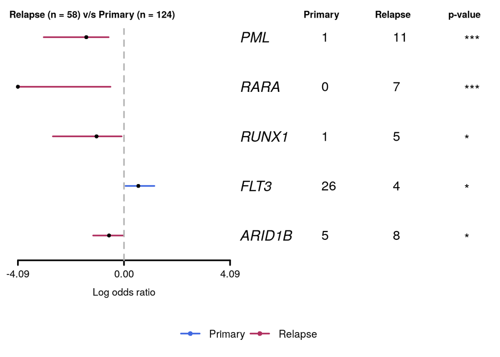

```r
forestPlot(mafCompareRes = pt.vs.rt, pVal = 0.1)
```

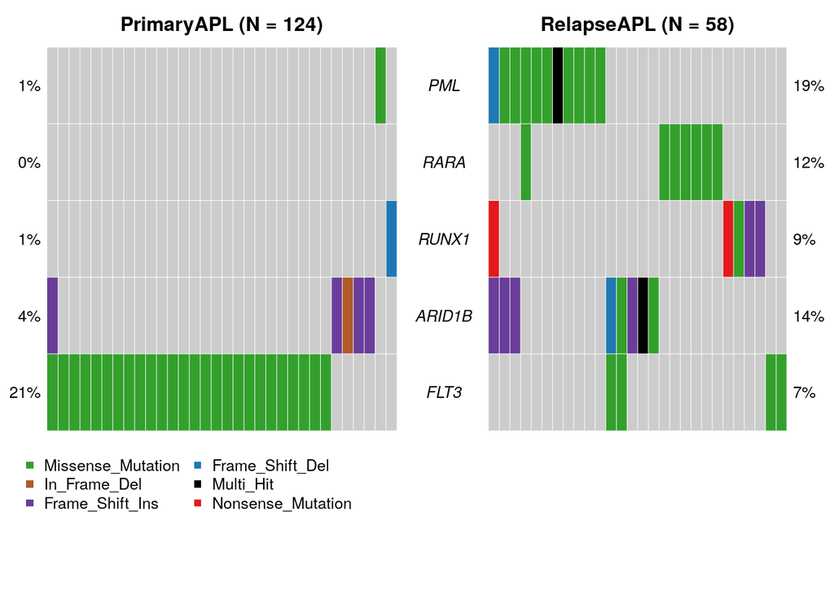

```r
genes = c("PML", "RARA", "RUNX1", "ARID1B", "FLT3")
coOncoplot(m1 = primary.apl, m2 = relapse.apl, m1Name = 'PrimaryAPL', m2Name = 'RelapseAPL', genes = genes, removeNonMutated = TRUE)
```

### Lollipop plot

This lollipop plot shows the distribution and types of mutations in the PML gene for primary and relapse cases. A higher mutation frequency in relapse cases (18.97%) versus primary cases (0.81%) suggests these mutations could play a role in disease progression or treatment resistance.

```
## 9 transcripts available. Use arguments refSeqID or proteinID to manually specify tx name.
```

```
##    HGNC refseq.ID protein.ID aa.length
## 1:  PML NM_033238  NP_150241       882
## 2:  PML NM_002675  NP_002666       633
## 3:  PML NM_033249  NP_150252       585
## 4:  PML NM_033247  NP_150250       435
## 5:  PML NM_033239  NP_150242       829
## 6:  PML NM_033250  NP_150253       781
## 7:  PML NM_033240  NP_150243       611
## 8:  PML NM_033244  NP_150247       560
## 9:  PML NM_033246  NP_150249       423
```

```
## Using longer transcript NM_033238 for now.
## 9 transcripts available. Use arguments refSeqID or proteinID to manually specify tx name.
```

```
##    HGNC refseq.ID protein.ID aa.length
## 1:  PML NM_033238  NP_150241       882
## 2:  PML NM_002675  NP_002666       633
## 3:  PML NM_033249  NP_150252       585
## 4:  PML NM_033247  NP_150250       435
## 5:  PML NM_033239  NP_150242       829
## 6:  PML NM_033250  NP_150253       781
## 7:  PML NM_033240  NP_150243       611
## 8:  PML NM_033244  NP_150247       560
## 9:  PML NM_033246  NP_150249       423
```

```
## Using longer transcript NM_033238 for now.
```

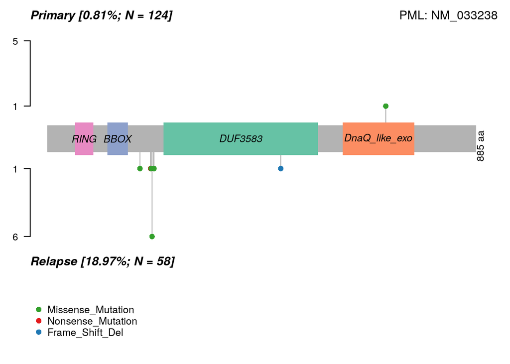

```r
lollipopPlot2(m1 = primary.apl, m2 = relapse.apl, gene = "PML", AACol1 = "amino_acid_change", AACol2 = "amino_acid_change", m1_name = "Primary", m2_name = "Relapse")
```

### Clinical enrichment analysis

```r
fab.ce = clinicalEnrichment(maf = laml, clinicalFeature = 'FAB_classification')
```

```
## Sample size per factor in FAB_classification:
```

```
##
## M0 M1 M2 M3 M4 M5 M6 M7
## 19 44 44 21 39 19  3  3
```

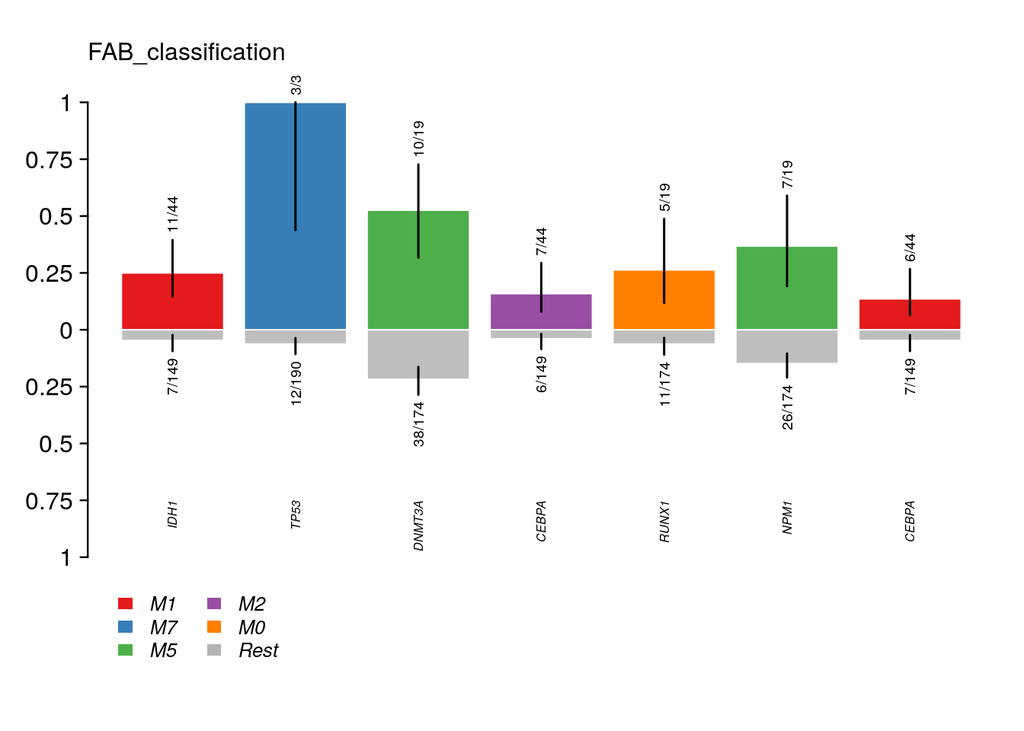

```r
plotEnrichmentResults(enrich_res = fab.ce, pVal = 0.05, geneFontSize = 0.5, annoFontSize = 0.6)
```

### Drug-Gene Interactions

```r
dgi = drugInteractions(maf = laml, fontSize = 0.75)
```

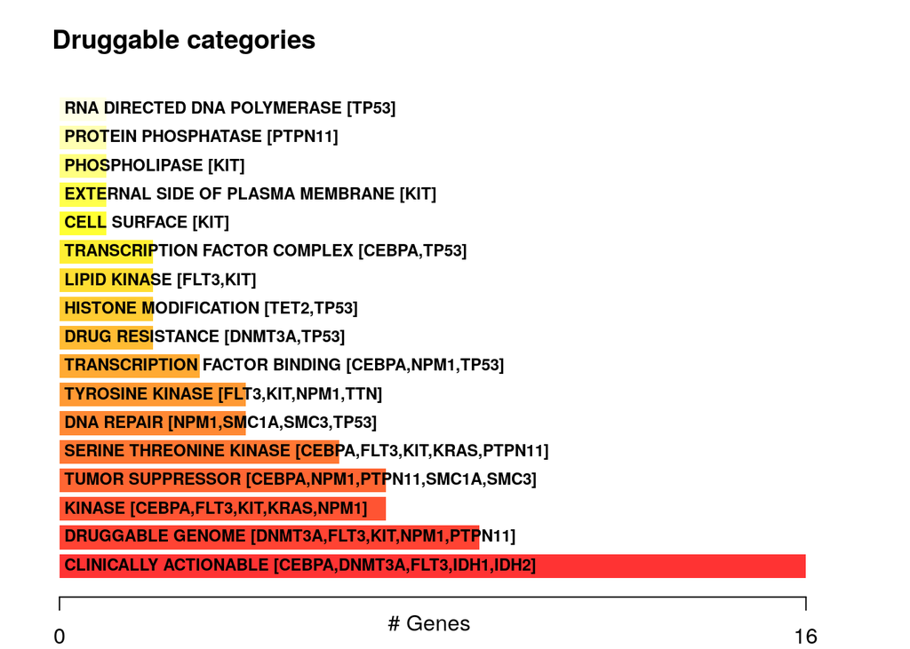

```r
dnmt3a.dgi = drugInteractions(genes = "DNMT3A", drugs = TRUE)
```

```
## Number of claimed drugs for given genes:
##      Gene N
## 1: DNMT3A 7
```

```r
dnmt3a.dgi[,.(Gene, interaction_types, drug_name, drug_claim_name)]
```

```
##      Gene interaction_types    drug_name drug_claim_name
## 1: DNMT3A                                            N/A
## 2: DNMT3A                   DAUNORUBICIN    Daunorubicin
## 3: DNMT3A                     DECITABINE      Decitabine
## 4: DNMT3A                     IDARUBICIN      IDARUBICIN
## 5: DNMT3A                     DECITABINE      DECITABINE
## 6: DNMT3A         inhibitor   DECITABINE   CHEMBL1201129
## 7: DNMT3A         inhibitor  AZACITIDINE      CHEMBL1489
```

### Oncogenic Signaling Pathways

This plot shows the fraction of different cancer-related pathways affected in a sample set, comparing the fraction within a specific subset (e.g., RTK-RAS pathway) to the overall sample population. This plot can assist with identifying those pathways most significantly affected by cancer diagnosis.

```r
OncogenicPathways(maf = laml)
```

```
## Pathway alteration fractions
```

```
##        Pathway  N n_affected_genes fraction_affected
##  1:    RTK-RAS 85               18        0.21176471
##  2:      Hippo 38                7        0.18421053
##  3:      NOTCH 71                6        0.08450704
##  4:        MYC 13                3        0.23076923
##  5:        WNT 68                3        0.04411765
##  6:       TP53  6                2        0.33333333
##  7:       NRF2  3                1        0.33333333
##  8:       PI3K 29                1        0.03448276
##  9: Cell_Cycle 15                0        0.00000000
## 10:   TGF-Beta  7                0        0.00000000
```

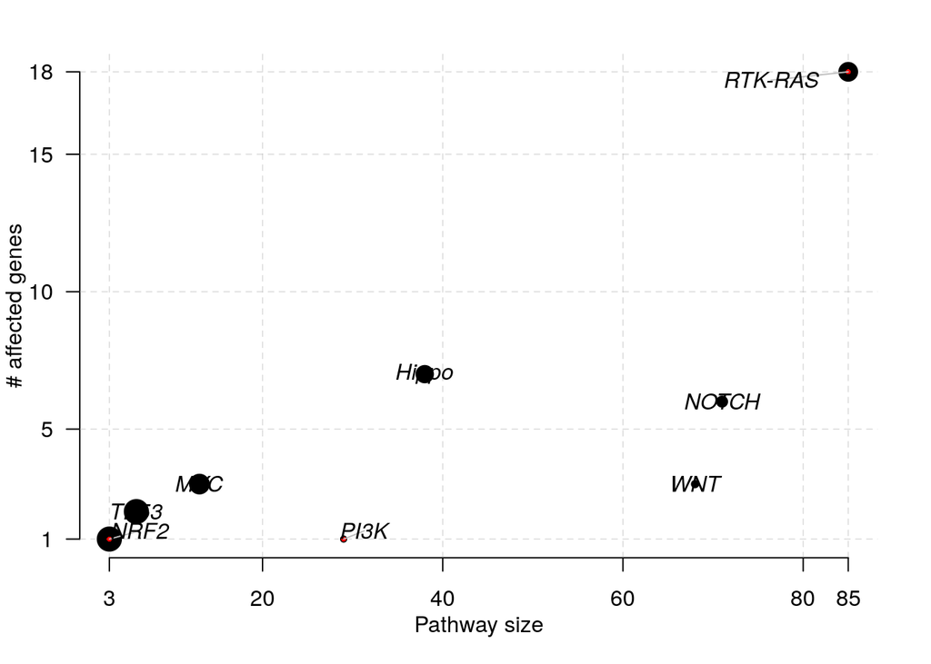

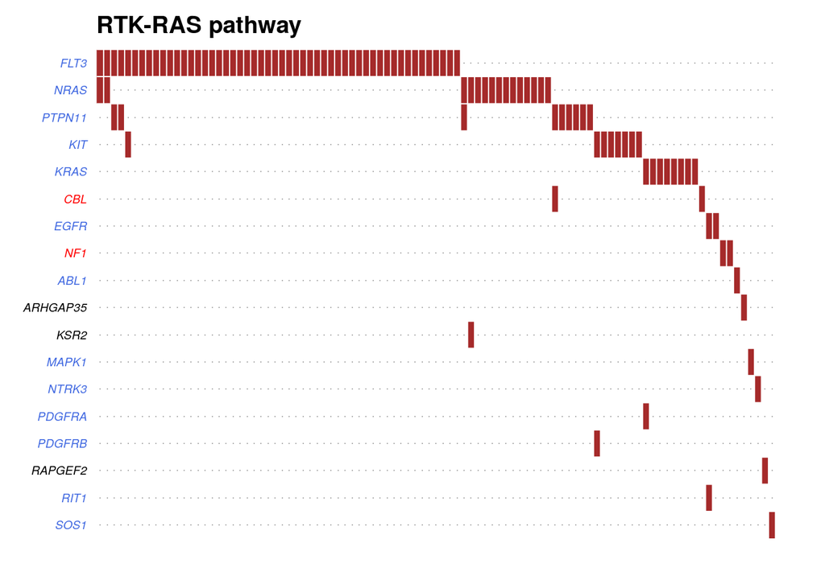

```r
PlotOncogenicPathways(maf = laml, pathways = "RTK-RAS")
```

# Conclusion

Through the provided `maftools` tutorial, we’ve gained the toolset to manipulate and interpret cancer data. We’ve learned how to read and summarize Mutation Annotation Format (`MAF`) files, which are critical for storing extensive genomic mutation data. The various plots and visualizations, such as oncoplots and waterfall plots are important in the exploration of mutational patterns and mutated genes identification within a cohort.

Analysis tools within `maftools`, including survival analysis and tumor mutation burden calculation, allow us to better understand the significance of cancer causing genes within a diagnosis.

By utilizing these tools, we can extract meaningful conclusions from complex genomic or multiomic data-sets. These insights are indespensable for improving surviveability and prescribing personalized medicine in oncology. For example, identifying recurrent mutations in a patient’s tumor profile could guide the selection of targeted therapies that are more likely to be effective against their specific cancer type. Survival analysis and mutation burden estimation are critical for prognosis and making informed decisions about dose and drug intensity.

While `maftools` provides a solid foundation for cancer genomic analysis, a more robust cancer identification pipeline might integrate additional data-sets (transcriptomic or methylomic), and utilize machine learning algorithms to predict treatment outcomes or identify novel therapeutic targets. Complementary tools like Genome Analysis Toolkit (GATK), known for its sophisticated variant discovery in high-throughput sequencing data, can complement the capabilities of `maftools`. These tool-sets combined can increase the power of patient care and treatment.

# References

1. Cancer Genome Atlas Research, N. Genomic and epigenomic landscapes of adult de novo acute myeloid leukemia. N Engl J Med 368, 2059-74 (2013).
2. David Tamborero, Abel Gonzalez-Perez, Nuria Lopez-Bigas, OncodriveCLUST: exploiting the positional clustering of somatic mutations to identify cancer genes, *Bioinformatics*, Volume 29, Issue 18, September 2013, Pages 2238–2244, https://doi.org/10.1093/bioinformatics/btt395
3. Mayakonda A, Lin DC, Assenov Y, Plass C, Koeffler HP. 2018. Maftools: efficient and comprehensive analysis of somatic variants in cancer. [Genome Resarch. PMID: 30341162](https://doi.org/10.1101/gr.239244.118)